# Sa

# comparación tomando todos como uno solo ————

```r
comparacionportecnicaymes <- aov(Promedio~tecnica, data=df)
comparacionportecnicaymes
```

```
Call:
   aov(formula = Promedio ~ tecnica, data = df)

Terms:
                 tecnica Residuals
Sum of Squares    297.44  36979.31
Deg. of Freedom        1        67

Residual standard error: 23.49319
Estimated effects may be unbalanced
7 observations deleted due to missingness
```

```r
summary(comparacionportecnicaymes)
```

```
            Df Sum Sq Mean Sq F value Pr(>F)
tecnica      1    297   297.4   0.539  0.465
Residuals   67  36979   551.9
7 observations deleted due to missingness
```

# medidas repetidas ————

```r
repetida <- aov(Promedio ~ tecnica*medicion + Error(n), df)
repetida
```

```
Call:
aov(formula = Promedio ~ tecnica * medicion + Error(n), data = df)

Grand Mean: 80.15072

Stratum 1: n

Terms:
                 tecnica
Sum of Squares  143.5424
Deg. of Freedom        1

2 out of 3 effects not estimable
Estimated effects are balanced

Stratum 2: Within

Terms:
                 tecnica medicion tecnica:medicion
Sum of Squares    292.67    28.36           322.41
Deg. of Freedom        1        1                1
                Residuals
Sum of Squares   36489.77
Deg. of Freedom        64

Residual standard error: 23.87787
Estimated effects may be unbalanced
```

```r
summary(repetida)
```

```
Error: n
        Df Sum Sq Mean Sq
tecnica  1  143.5   143.5

Error: Within
                 Df Sum Sq Mean Sq F value Pr(>F)
tecnica           1    293   292.7   0.513  0.476
medicion          1     28    28.4   0.050  0.824
tecnica:medicion  1    322   322.4   0.565  0.455
Residuals        64  36490   570.2
```

# atendieron el mismo tipo de paciente los colegas?

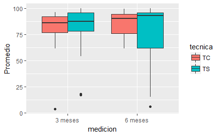

```r
q <- ggplot(aes(y = Promedio, x = medicion, fill = tecnica), data = df)
p <- q + geom_boxplot()  # más puntos + geom_jitter(width = 0.2) # para ver por factores + (aes(colour = FACTOR))
p
```

# Tabla 1 ———–

```r
table(df$tecnica)
```

```
TC TS
34 42
```

```r
tapply(df$edad, df$tecnica, mean)
```

```
      TC       TS
71.79412 73.07143
```

```r
tapply(df$edad, df$tecnica, sd)
```

```
      TC       TS
7.650626 6.122302
```

```r
t.test(df$edad~df$tecnica)
```

```
    Welch Two Sample t-test

data:  df$edad by df$tecnica
t = -0.79003, df = 62.553, p-value = 0.4325
alternative hypothesis: true difference in means is not equal to 0
95 percent confidence interval:
 -4.508638  1.954016
sample estimates:
mean in group TC mean in group TS
        71.79412         73.07143
```

```r
sexoxtecnica <- table(df$sexo, df$tecnica)
sexoxtecnica
```

```
    TC TS
  F 18 34
  M 16  8
```

```r
chisq.test(sexoxtecnica)
```

```
    Pearson's Chi-squared test with Yates'
    continuity correction

data:  sexoxtecnica
X-squared = 5.5884, df = 1, p-value = 0.01808
```

```r
maxilar <- table(df$clasif.max, df$tecnica)
table(df$clasif.mand, df$tecnica)
```

```
    TC TS
  3  8  8
  4 18 24
  5  6 10
```

```r
chisq.test(table(df$clasif.max, df$tecnica))
```

```
Chi-squared approximation may be incorrect
```

```
    Pearson's Chi-squared test with Yates'
    continuity correction

data:  table(df$clasif.max, df$tecnica)
X-squared = 1.5679, df = 1, p-value = 0.2105
```

```r
chisq.test(table(df$clasif.mand, df$tecnica))
```

```
    Pearson's Chi-squared test

data:  table(df$clasif.mand, df$tecnica)
X-squared = 0.5152, df = 2, p-value = 0.7729
```

# Datos de base, medición 1 ————

```r
df_inicio <- subset(df, df$medicion=="3 meses")
df_final <- subset(df, df$medicion=="6 meses")
str(df_inicio)
```

```
'data.frame':   38 obs. of  25 variables:
 $ n          : int  1 2 3 4 5 6 7 8 9 10 ...
 $ medicion   : Factor w/ 2 levels "3 meses","6 meses": 1 1 1 1 1 1 1 1 1 1 ...
 $ operador   : Factor w/ 3 levels "FS","IQ","ML": 3 3 3 3 2 2 2 1 1 2 ...
 $ sexo       : Factor w/ 2 levels "F","M": 2 1 1 1 1 1 1 1 2 1 ...
 $ edad       : int  57 72 74 65 77 72 76 66 77 80 ...
 $ clasif.max : Factor w/ 2 levels "3","4": 1 2 1 2 1 NA 1 1 1 1 ...
 $ clasif.mand: Factor w/ 3 levels "3","4","5": 1 2 1 2 2 NA 2 3 1 2 ...
 $ tecnica    : Factor w/ 2 levels "TC","TS": 1 2 1 2 1 1 2 2 1 2 ...
 $ x1.1       : num  84 98 96 6 80 77 92 94 98 98 ...
 $ x2.1       : num  96 97 97 6 93 97 91 94 96 98 ...
 $ x2.2       : num  69 98 58 36 66 14 92 94 94 98 ...
 $ x3.1       : num  94 97 95 5 85 98 93 92 95 98 ...
 $ x3.2       : num  47 93 96 4 72 8 8 34 94 97 ...
 $ x4.1       : num  94 99 89 2 94 97 85 91 96 98 ...
 $ x4.2       : num  28 95 59 4 69 21 72 91 96 92 ...
 $ x5.1       : num  94 99 88 4 94 97 86 90 94 97 ...
 $ x5.2       : num  83 99 60 4 94 7 97 91 94 97 ...
 $ x6.1       : num  94 98 87 3 94 98 92 91 97 96 ...
 $ x6.2       : num  16 51 56 2 76 8 85 41 95 97 ...
 $ x7.1       : num  96 98 88 92 93 99 9 91 94 97 ...
 $ x7.2       : num  95 98 88 96 94 97 91 89 95 97 ...
 $ x8.1       : num  94 99 87 3 95 98 9 90 95 98 ...
 $ x8.2       : num  95 99 84 4 94 10 89 90 94 98 ...
 $ experto    : int  NA NA NA NA NA NA NA NA NA NA ...
 $ Promedio   : num  78.6 94.5 81.9 18.1 86.2 ...
```

```r
str(df_final)
```

```
'data.frame':   38 obs. of  25 variables:
 $ n          : int  1 2 3 4 5 6 7 8 9 10 ...
 $ medicion   : Factor w/ 2 levels "3 meses","6 meses": 2 2 2 2 2 2 2 2 2 2 ...
 $ operador   : Factor w/ 3 levels "FS","IQ","ML": 3 3 3 3 2 2 2 1 1 2 ...
 $ sexo       : Factor w/ 2 levels "F","M": 2 1 1 1 1 1 1 1 2 1 ...
 $ edad       : int  57 72 74 65 77 72 76 66 77 80 ...
 $ clasif.max : Factor w/ 2 levels "3","4": 1 2 1 2 1 NA 1 1 1 1 ...
 $ clasif.mand: Factor w/ 3 levels "3","4","5": 1 2 1 2 2 NA 2 3 1 2 ...
 $ tecnica    : Factor w/ 2 levels "TC","TS": 1 2 1 2 1 1 2 2 1 2 ...
 $ x1.1       : num  55 83 98 3 74 95 94 95 100 97 ...
 $ x2.1       : num  100 84 99 3 96 95 94 96 98 98 ...
 $ x2.2       : num  0 84 94 2 84 44 95 95 96 97 ...
 $ x3.1       : num  100 83 98 4 94 93 92 96 96 96 ...
 $ x3.2       : num  6 55 94 4 88 60 94 95 96 95 ...
 $ x4.1       : num  100 79 98 3 93 93 92 96 94 96 ...
 $ x4.2       : num  7 54 99 3 90 57 92 96 92 78 ...
 $ x5.1       : num  100 83 99 2 93 93 85 95 93 89 ...
 $ x5.2       : num  5 56 99 3 88 56 88 95 91 89 ...
 $ x6.1       : num  100 83 99 2 95 93 90 96 97 95 ...
 $ x6.2       : num  5 46 90 2 95 7 87 94 95 77 ...
 $ x7.1       : num  100 83 99 97 95 96 82 94 94 96 ...
 $ x7.2       : num  43 83 99 97 96 95 82 95 92 95 ...
 $ x8.1       : num  100 87 99 3 93 97 87 95 92 96 ...
 $ x8.2       : num  100 85 99 2 97 35 87 95 90 95 ...
 $ experto    : int  71 88 88 0 94 74 99 100 100 96 ...
 $ Promedio   : num  61.4 75.2 97.5 15.3 91.4 ...
```

```r
table(df_inicio$SEXO)
```

```
< table of extent 0 >
```

```r
table(df_inicio$tecnica)
```

```
TC TS
17 21
```

```r
tapply(df_inicio$edad, df_inicio$tecnica, mean)
```

```
      TC       TS
71.82353 73.04762
```

# Tabla 1 ———-

```r
tapply(df_inicio$edad, df_inicio$tecnica, sd)
```

```
      TC       TS
7.780065 6.192545
```

```r
t.test(df_inicio$edad~df_inicio$tecnica)
```

```
    Welch Two Sample t-test

data:  df_inicio$edad by df_inicio$tecnica
t = -0.52742, df = 30.254, p-value = 0.6018
alternative hypothesis: true difference in means is not equal to 0
95 percent confidence interval:
 -5.962356  3.514176
sample estimates:
mean in group TC mean in group TS
        71.82353         73.04762
```

```r
sexoxtecnica <- table(df_inicio$sexo, df_inicio$tecnica)
sexoxtecnica
```

```
    TC TS
  F  9 17
  M  8  4
```

```r
chisq.test(sexoxtecnica)
```

```
    Pearson's Chi-squared test with Yates'
    continuity correction

data:  sexoxtecnica
X-squared = 2.2384, df = 1, p-value = 0.1346
```

```r
fisher.test(sexoxtecnica)
```

```
    Fisher's Exact Test for Count Data

data:  sexoxtecnica
p-value = 0.08733
alternative hypothesis: true odds ratio is not equal to 1
95 percent confidence interval:
 0.04660678 1.36907795
sample estimates:
odds ratio
 0.2748071
```

```r
table(df_inicio$clasif.max, df_inicio$tecnica); fisher.test(table(df_inicio$clasif.max, df_inicio$tecnica))
```

```
    TC TS
  3 15 17
  4  1  4

    Fisher's Exact Test for Count Data

data:  table(df_inicio$clasif.max, df_inicio$tecnica)
p-value = 0.3641
alternative hypothesis: true odds ratio is not equal to 1
95 percent confidence interval:
   0.2947116 184.9977375
sample estimates:
odds ratio
  3.423829
```

```r
table(df_inicio$clasif.mand, df_inicio$tecnica); fisher.test(table(df_inicio$clasif.mand, df_inicio$tecnica))
```

```
    TC TS
  3  4  4
  4  9 12
  5  3  5

    Fisher's Exact Test for Count Data

data:  table(df_inicio$clasif.mand, df_inicio$tecnica)
p-value = 1
alternative hypothesis: two.sided
```

# Tabla 2 ————–

```r
tabla2.1.1 <- aggregate(df$x1.1, list(Tecnica= df$tecnica, Medición=df$medicion), mean, na.rm=T)
tabla2.1.1
```

| Tecnica | Medición | x |
| --- | --- | --- |
| TC | 3 meses | 79.23529 |
| TS | 3 meses | 80.05000 |
| TC | 6 meses | 81.78571 |
| TS | 6 meses | 78.38889 |

```r
tbl_df(df)
```

| n | medicion | operador | sexo | edad | clasif.max | clasif.mand | tecnica | x1.1 | x2.1 | x2.2 | x3.1 | x3.2 | x4.1 | x4.2 | x5.1 | x5.2 | x6.1 | x6.2 | x7.1 | x7.2 | x8.1 | x8.2 | experto | Promedio |
| --- | --- | --- | --- | --- | --- | --- | --- | --- | --- | --- | --- | --- | --- | --- | --- | --- | --- | --- | --- | --- | --- | --- | --- | --- |
| 1 | 3 meses | ML | M | 57 | 3 | 3 | TC | 84 | 96 | 69 | 94 | 47 | 94 | 28 | 94 | 83 | 94 | 16 | 96 | 95 | 94 | 95 | NA | 78.600000 |
| 2 | 3 meses | ML | F | 72 | 4 | 4 | TS | 98 | 97 | 98 | 97 | 93 | 99 | 95 | 99 | 99 | 98 | 51 | 98 | 98 | 99 | 99 | NA | 94.533333 |
| 3 | 3 meses | ML | F | 74 | 3 | 3 | TC | 96 | 97 | 58 | 95 | 96 | 89 | 59 | 88 | 60 | 87 | 56 | 88 | 88 | 87 | 84 | NA | 81.866667 |
| 4 | 3 meses | ML | F | 65 | 4 | 4 | TS | 6 | 6 | 36 | 5 | 4 | 2 | 4 | 4 | 4 | 3 | 2 | 92 | 96 | 3 | 4 | NA | 18.066667 |
| 5 | 3 meses | IQ | F | 77 | 3 | 4 | TC | 80 | 93 | 66 | 85 | 72 | 94 | 69 | 94 | 94 | 94 | 76 | 93 | 94 | 95 | 94 | NA | 86.200000 |
| 6 | 3 meses | IQ | F | 72 | NA | NA | TC | 77 | 97 | 14 | 98 | 8 | 97 | 21 | 97 | 7 | 98 | 8 | 99 | 97 | 98 | 10 | NA | 61.733333 |
| 7 | 3 meses | IQ | F | 76 | 3 | 4 | TS | 92 | 91 | 92 | 93 | 8 | 85 | 72 | 86 | 97 | 92 | 85 | 9 | 91 | 9 | 89 | NA | 72.733333 |
| 8 | 3 meses | FS | F | 66 | 3 | 5 | TS | 94 | 94 | 94 | 92 | 34 | 91 | 91 | 90 | 91 | 91 | 41 | 91 | 89 | 90 | 90 | NA | 84.200000 |
| 9 | 3 meses | FS | M | 77 | 3 | 3 | TC | 98 | 96 | 94 | 95 | 94 | 96 | 96 | 94 | 94 | 97 | 95 | 94 | 95 | 95 | 94 | NA | 95.133333 |
| 10 | 3 meses | IQ | F | 80 | 3 | 4 | TS | 98 | 98 | 98 | 98 | 97 | 98 | 92 | 97 | 97 | 96 | 97 | 97 | 97 | 98 | 98 | NA | 97.066667 |

[output cut: 66 more lines]

```r
df_prepost <- as.data.frame(split(df, df$medicion))
```

```r
df_prepost$difX.2.1 <- df_prepost$X6.meses.x2.1 - df_prepost$X3.meses.x2.1 # columna 51
df_prepost$difX.2.2 <- df_prepost$X6.meses.x2.2 - df_prepost$X3.meses.x2.2
df_prepost$difX.3.1 <- df_prepost$X6.meses.x3.1 - df_prepost$X3.meses.x3.1
df_prepost$difX.3.2 <- df_prepost$X6.meses.x3.2 - df_prepost$X3.meses.x3.2
df_prepost$difX.4.1 <- df_prepost$X6.meses.x4.1 - df_prepost$X3.meses.x4.1
df_prepost$difX.4.2 <- df_prepost$X6.meses.x4.2 - df_prepost$X3.meses.x4.2
df_prepost$difX.5.1 <- df_prepost$X6.meses.x5.1 - df_prepost$X3.meses.x5.1
df_prepost$difX.5.2 <- df_prepost$X6.meses.x5.2 - df_prepost$X3.meses.x5.2
df_prepost$difX.6.1 <- df_prepost$X6.meses.x6.1 - df_prepost$X3.meses.x6.1
df_prepost$difX.6.2 <- df_prepost$X6.meses.x6.2 - df_prepost$X3.meses.x6.2
df_prepost$difX.7.1 <- df_prepost$X6.meses.x7.1 - df_prepost$X3.meses.x7.1
df_prepost$difX.7.2 <- df_prepost$X6.meses.x7.2 - df_prepost$X3.meses.x7.2
df_prepost$difX.8.1 <- df_prepost$X6.meses.x8.1 - df_prepost$X3.meses.x8.1
df_prepost$difX.8.2 <- df_prepost$X6.meses.x8.2 - df_prepost$X3.meses.x8.2 # columna 64
```

# convirtiendo wide to long

```r
head(df$tecnica)
```

```
[1] TC TS TC TS TC TC
Levels: TC TS
```

[output not shown]

```r
t.test(x1.1~tecnica, data=antes)
```

[output not shown]

```r
# divido por técnica
tc <- df[which(df$tecnica=="TC"),]
ts <- df[which(df$tecnica=="TS"),]
head(tc)
head(ts)
```

[output not shown]

# comparaciones antes

plot(x1.1~medicion, data=tc) t.test(Promedio~medicion, data=tc)

t.test(x1.1~medicion, data=tc) t.test(x2.1~medicion, data=tc) t.test(x2.2~medicion, data=tc) t.test(x3.1~medicion, data=tc) t.test(x3.2~medicion, data=tc) t.test(x4.1~medicion, data=tc) t.test(x4.2~medicion, data=tc) t.test(x5.1~medicion, data=tc) t.test(x5.2~medicion, data=tc) t.test(x6.1~medicion, data=tc) t.test(x6.2~medicion, data=tc) t.test(x7.1~medicion, data=tc) t.test(x7.2~medicion, data=tc) t.test(x8.1~medicion, data=tc) t.test(x8.2~medicion, data=tc)

# comparaciones despues

t.test(Promedio~medicion, data=ts) t.test(x1.1~medicion, data=ts) t.test(x2.1~medicion, data=ts) t.test(x2.2~medicion, data=ts) t.test(x3.1~medicion, data=ts) t.test(x3.2~medicion, data=ts) t.test(x4.1~medicion, data=ts) t.test(x4.2~medicion, data=ts) t.test(x5.1~medicion, data=ts) t.test(x5.2~medicion, data=ts) t.test(x6.1~medicion, data=ts) t.test(x6.2~medicion, data=ts) t.test(x7.1~medicion, data=ts) t.test(x7.2~medicion, data=ts) t.test(x8.1~medicion, data=ts) t.test(x8.2~medicion, data=ts)

# ver http://www.wekaleamstudios.co.uk/posts/analysis-of-covariance-extending-simple-linear-regression/

mod1 <- lm(Promedio ~ tecnica, data = long) summary(mod1)

# ahora asumo para cada paciente

mod2 <- lm(Promedio ~ tecnica + medicion, data = long) summary(mod2)

# comparo los modelos

anova(mod1, mod2)

# otro

mod3 <- lm(Promedio ~ sexo + clasif.max + clasif.mand + tecnica, data = long) mod4 <- lm(Promedio ~ tecnica, data = long) summary(mod3) anova(mod3)

# ANOVA

final <- long[which(long$medicion==“6 meses”), ] head(final) mod5 <- lm(Promedio ~ tecnica + sexo + clasif.mand + clasif.max, data = final) summary(mod5) anova(mod5) tapply(final$Promedio, final$tecnica, mean, na.rm=T) #parece que si hay diferencia, 85 para TC y 76 para TS tapply(final$experto, final$tecnica, mean, na.rm=T) t.test(final$experto, final$Promedio) #no hay diferencia entre la evaluación del experto y el Promedio

p <- ggplot(data= df, aes(factor(medicion), y=Promedio))

p + geom_boxplot(aes(fill = factor(tecnica))) + labs(list(title = “Quality comparison by group at 3 and 6 months”, x = “Month”, y = “Quality average”)) + theme_minimal() + scale_fill_discrete(guide = guide_legend(title = “Group”), labels = c(“Conventional”, “Simplified”)) + scale_x_discrete(“Month”, labels = c(“3”, “6”))

[output not shown]